# PanelCheck — R Analysis Report

## Assessor Flag Summary

A concise QC summary — one row per assessor — aggregating performance across all attributes. Each domain (agreement, repeatability, discrimination) is flagged independently; no single composite score is produced. 🟢 PASS · 🟡 MONITOR · 🔴 CONCERN · ⬜ Insufficient data.

```r
if (!is.null(tables[["assessor_flag_summary"]])) {
  dt <- tables[["assessor_flag_summary"]] |>
    mutate(across(where(is.numeric), \(x) round(x, 2))) |>
    datatable(
      filter    = "top",
      rownames  = FALSE,
      extensions = "Buttons",
      options   = list(
        dom        = "Bfrtip",
        buttons    = c("csv", "excel"),
        pageLength = 20,
        scrollX    = TRUE
      ),
      caption = htmltools::tags$caption(
        style = "caption-side: top; text-align: left;",
        "Table 4a. Assessor flag summary — per-domain QC flags aggregated across attributes."
      )
    )
  # Apply background colours to all flag columns (columns ending in _flag)
  flag_cols <- grep("_flag$", names(tables[["assessor_flag_summary"]]), value = TRUE)
  for (fc in flag_cols) dt <- .dt_flag_colours(dt, fc)
  dt
} else {
  cat("*Assessor flag summary table not available — re-run `run_all.R` to generate.*")
}
```

| Assessor | mean_r | agreement_flag | agreement_descriptor | mean_cv | repeatability_flag | repeatability_descriptor | pct_sig_disc | discrimination_flag | discrimination_descriptor |
| --- | --- | --- | --- | --- | --- | --- | --- | --- | --- |
| AS1 | 0.79 | 🟡 | Moderate agreement — monitor | 53.44 | 🔴 | Poor repeatability — investigate | 20 | 🔴 | Poor discrimination — cannot distinguish samples |
| AS2 | 0.87 | 🟢 | Strong agreement | 41.99 | 🔴 | Poor repeatability — investigate | 70 | 🟢 | Discriminates reliably on majority of attributes |
| AS3 | 0.83 | 🟢 | Strong agreement | 43.55 | 🔴 | Poor repeatability — investigate | 50 | 🟢 | Discriminates reliably on majority of attributes |
| AS4 | 0.86 | 🟢 | Strong agreement | 41.97 | 🔴 | Poor repeatability — investigate | 20 | 🔴 | Poor discrimination — cannot distinguish samples |
| AS5 | 0.79 | 🟡 | Moderate agreement — monitor | 43.76 | 🔴 | Poor repeatability — investigate | 40 | 🟡 | Marginal discrimination — monitor |
| AS6 | 0.61 | 🟡 | Moderate agreement — monitor | 59.74 | 🔴 | Poor repeatability — investigate | 40 | 🟡 | Marginal discrimination — monitor |
| AS7 | 0.75 | 🟡 | Moderate agreement — monitor | 63.27 | 🔴 | Poor repeatability — investigate | 40 | 🟡 | Marginal discrimination — monitor |
| AS8 | 0.95 | 🟢 | Strong agreement | 34.41 | 🟡 | Marginal repeatability — monitor | 70 | 🟢 | Discriminates reliably on majority of attributes |

> ⚠️ **Note:** Performance flags are based on widely used guidelines in sensory science. Thresholds may be adjusted to reflect panel context, product category, and institutional SOPs.

## Discrimination

One-way ANOVA per assessor per attribute. The F-value indicates how well each assessor distinguishes between samples on that attribute — a higher F-value reflects stronger discrimination.

```r
.dt_flag_rows(
  tables[["assessor_discrimination"]],
  caption     = "Table 5. One-way ANOVA F-values per assessor and attribute.",
  page_length = 15
)
```

| Assessor | Attribute | F_value | p_value | sig | mean_score | flag | descriptor |
| --- | --- | --- | --- | --- | --- | --- | --- |
| AS1 | Bread-od | 10.75 | 0.01 | * | 2.2 | 🟢 | Discriminates samples reliably |
| AS1 | Yeast-od | 2.33 | 0.19 | ns | 1.1 | 🔴 | Poor discrimination — cannot distinguish samples |
| AS1 | Off-flav | 0 | 1 | ns | 0 | 🔴 | Poor discrimination — cannot distinguish samples |
| AS1 | Colour | 1.21 | 0.41 | ns | 1.9 | 🔴 | Poor discrimination — cannot distinguish samples |
| AS1 | Moisture | 0.97 | 0.5 | ns | 3 | 🔴 | Poor discrimination — cannot distinguish samples |
| AS1 | Tough | 4.89 | 0.06 | . | 1.7 | 🟡 | Borderline discrimination |
| AS1 | Salt-t | 3.83 | 0.09 | . | 0.7 | 🟡 | Borderline discrimination |
| AS1 | Sweet-t | 1.75 | 0.28 | ns | 0.4 | 🔴 | Poor discrimination — cannot distinguish samples |
| AS1 | Yeast-t | 3 | 0.13 | ns | 1.1 | 🔴 | Poor discrimination — cannot distinguish samples |
| AS1 | Other-t | 81 | 0 | *** | 0.9 | 🟢 | Discriminates samples reliably |

[output cut: 70 more lines]

*Significance key:* `***` p < 0.001 · `**` p < 0.01 · `*` p < 0.05 · `ns` p ≥ 0.05 · Row colour: 🟢 p ≤ 0.05 · 🟡 p ≤ 0.10 · 🔴 p > 0.10

> ⚠️ **Note:** Performance flags are based on widely used guidelines in sensory science. Thresholds may be adjusted to reflect panel context, product category, and institutional SOPs.

## Discrimination Bars

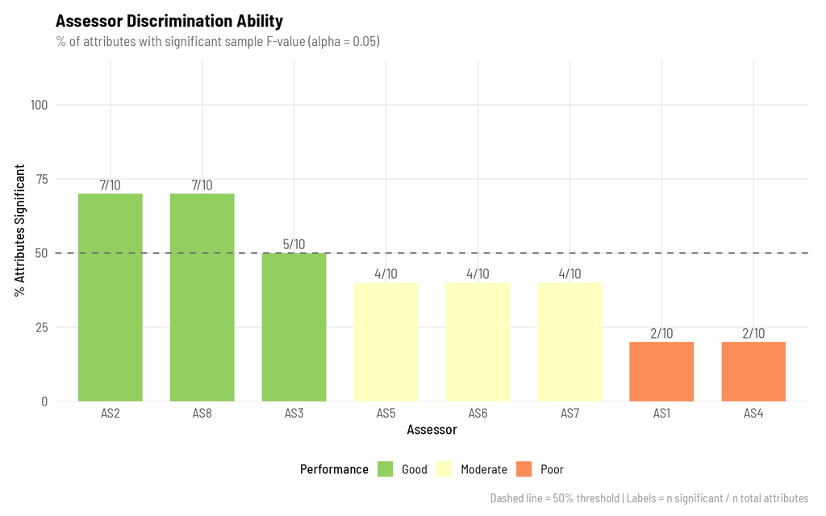

```r
knitr::include_graphics("figs/R/discrimination_bars.png")
```

## Repeatability ANOVA

Two-way additive fixed-effects ANOVA (`value ~ Sample + Replicate`, Type III SS) fitted per assessor × attribute. No Sample × Replicate interaction is included — with typically only two replicates this term cannot be estimated reliably. A significant **Sample** effect confirms the assessor discriminates between products; a significant **Replicate** effect indicates session-to-session inconsistency.

```r
.dt_flag_rows(
  tables[["repeatability_anova"]],
  caption     = "Table 8. Repeatability ANOVA results per assessor and attribute.",
  page_length = 15
)
```

| Assessor | Attribute | Effect | SS | df | MS | F_value | p_value | sig | flag | descriptor |
| --- | --- | --- | --- | --- | --- | --- | --- | --- | --- | --- |
| AS1 | Bread-od | Sample | 8.6 | 4 | 2.15 | 14.33 | 0.01 | * | 🟢 | Discriminates samples reliably |
| AS1 | Bread-od | Replicate | 0.4 | 1 | 0.4 | 2.67 | 0.18 | ns | 🟢 | No significant session effect — good repeatability |
| AS1 | Bread-od | Residual | 0.6 | 4 | 0.15 |  |  |  | ⬜ |  |
| AS1 | Yeast-od | Sample | 8.4 | 4 | 2.1 | 4.2 | 0.1 | . | 🟡 | Borderline discrimination |
| AS1 | Yeast-od | Replicate | 2.5 | 1 | 2.5 | 5 | 0.09 | . | 🟡 | Borderline session effect — monitor |
| AS1 | Yeast-od | Residual | 2 | 4 | 0.5 |  |  |  | ⬜ |  |
| AS1 | Off-flav | Sample | 0 | 4 | 0 | 0 | 1 | ns | 🔴 | Poor discrimination — cannot distinguish samples |
| AS1 | Off-flav | Replicate | 0 | 1 | 0 | 0 | 1 | ns | 🟢 | No significant session effect — good repeatability |
| AS1 | Off-flav | Residual | 0 | 4 | 0 |  |  |  | ⬜ |  |
| AS1 | Colour | Sample | 3.4 | 4 | 0.85 | 1.31 | 0.4 | ns | 🔴 | Poor discrimination — cannot distinguish samples |

[output cut: 220 more lines]

*Significance key:* `***` p < 0.001 · `**` p < 0.01 · `*` p < 0.05 · `ns` p ≥ 0.05 · Sample rows: 🟢 p ≤ 0.05 · 🔴 p > 0.10 · Replicate rows: 🟢 p > 0.10 (consistent) · 🔴 p ≤ 0.05 (session inconsistency)

> ⚠️ **Note:** Performance flags are based on widely used guidelines in sensory science. Thresholds may be adjusted to reflect panel context, product category, and institutional SOPs.

## Assessor Agreement

Pearson correlation of each assessor’s scores with the panel mean per attribute. Values approaching 1 indicate the assessor aligns closely with the panel consensus; values near 0 or negative indicate systematic disagreement or scale reversal.

```r
.dt_flag_rows(
  tables[["assessor_agreement"]],
  caption     = "Table 9. Assessor agreement (Pearson r with panel mean) per assessor and attribute.",
  page_length = 15
)
```

| Assessor | Attribute | r | p_value | sig | flag | descriptor |
| --- | --- | --- | --- | --- | --- | --- |
| AS1 | Bread-od | -0.39 | 0.51 | ns | 🔴 | Inverse scoring — check scale direction |
| AS1 | Yeast-od | 0.86 | 0.06 | . | 🟢 | Strong agreement |
| AS1 | Off-flav |  |  |  | ⬜ | Insufficient data |
| AS1 | Colour | 0.94 | 0.02 | * | 🟢 | Strong agreement |
| AS1 | Moisture | 0.86 | 0.06 | . | 🟢 | Strong agreement |
| AS1 | Tough | 0.98 | 0 | ** | 🟢 | Strong agreement |
| AS1 | Salt-t | 0.98 | 0 | ** | 🟢 | Strong agreement |
| AS1 | Sweet-t | 0.88 | 0.05 | . | 🟢 | Strong agreement |
| AS1 | Yeast-t | 0.99 | 0 | ** | 🟢 | Strong agreement |
| AS1 | Other-t | 0.99 | 0 | ** | 🟢 | Strong agreement |

[output cut: 70 more lines]

*Significance key:* `***` p < 0.001 · `**` p < 0.01 · `*` p < 0.05 · `ns` p ≥ 0.05 · Row colour: 🟢 r ≥ 0.80 · 🟡 r ≥ 0.60 · 🔴 r < 0.60 or negative

> ⚠️ **Note:** Performance flags are based on widely used guidelines in sensory science. Thresholds may be adjusted to reflect panel context, product category, and institutional SOPs.

# Panel ANOVA

A three-way fixed-effects ANOVA is run per attribute at the panel level using `lm()` with sum-to-zero contrasts and `car::Anova()` (Type III sums of squares). All three structural terms — Sample, Assessor, and Replicate — are treated as **fixed effects** (contrast with the mixed model below, where Assessor is random). Type III SS with sum-to-zero contrasts ensures correct marginal F-tests for unbalanced designs. This decomposes variance into the following effects:

- **Sample** — significant product differences (the primary goal of profiling)
- **Assessor** — systematic differences in scale use between panellists
- **Replicate** — variation between repeat sessions; a significant effect indicates poor panel repeatability
- **Sample × Assessor** — interaction indicating disagreement in how assessors rank samples relative to one another (included only when all assessor × sample cells are observed; dropped automatically for incomplete designs)

F-ratios are computed as the marginal mean square for each effect divided by the residual mean square. Significance is evaluated against an F-distribution with the corresponding degrees of freedom.

## ANOVA F-Ratios

```r
.dt_plain(tables[["Table6_anova_Fratios"]],
          caption = "Table 6. Three-way fixed-effects ANOVA F-ratios per attribute (wide format). Each cell shows the rounded F-ratio and significance stars for the Sample, Panellist, and Replicate main effects. See Table 7 for full SS, df, MS, and interaction term detail.")
```

| Attribute | Sample | Panellist | Replicate |
| --- | --- | --- | --- |
| Bread-od | 1 ns | 3 * | 0 ns |
| Yeast-od | 12 *** | 4 ** | 0 ns |
| Off-flav | 25 *** | 21 *** | 1 ns |
| Colour | 10 *** | 3 * | 0 ns |
| Moisture | 24 *** | 3 ** | 1 ns |
| Tough | 34 *** | 3 * | 2 ns |
| Salt-t | 68 *** | 11 *** | 5 * |
| Sweet-t | 66 *** | 29 *** | 4 . |
| Yeast-t | 24 *** | 11 *** | 1 ns |
| Other-t | 68 *** | 7 *** | 0 ns |

*Significance key:* `***` p < 0.001 · `**` p < 0.01 · `*` p < 0.05 · `ns` p ≥ 0.05

## Panel ANOVA Detail

```r
.dt_plain(tables[["panel_anova"]],
          caption = "Table 7. Three-way fixed-effects ANOVA results in long format — one row per effect, reporting SS, df, MS, F, and p per attribute. Includes the Sample × Assessor interaction where design is complete.")
```

| Attribute | Effect | SS | df | MS | F_value | p_value | sig |
| --- | --- | --- | --- | --- | --- | --- | --- |
| Bread-od | Sample | 6.42 | 4 | 1.61 | 1.44 | 0.24 | ns |
| Bread-od | Assessor | 23.2 | 7 | 3.31 | 2.97 | 0.01 | * |
| Bread-od | Replicate | 0.45 | 1 | 0.45 | 0.4 | 0.53 | ns |
| Bread-od | Sample:Assessor | 46.17 | 28 | 1.65 | 1.48 | 0.13 | ns |
| Yeast-od | Sample | 46.05 | 4 | 11.51 | 12.15 | 0 | *** |
| Yeast-od | Assessor | 28.75 | 7 | 4.11 | 4.34 | 0 | ** |
| Yeast-od | Replicate | 0.05 | 1 | 0.05 | 0.05 | 0.82 | ns |
| Yeast-od | Sample:Assessor | 37.75 | 28 | 1.35 | 1.42 | 0.15 | ns |
| Off-flav | Sample | 68.38 | 4 | 17.09 | 24.79 | 0 | *** |
| Off-flav | Assessor | 100.49 | 7 | 14.36 | 20.82 | 0 | *** |

[output cut: 30 more lines]

*Significance key:* `***` p < 0.001 · `**` p < 0.01 · `*` p < 0.05 · `ns` p ≥ 0.05

## F-Value Heatmap

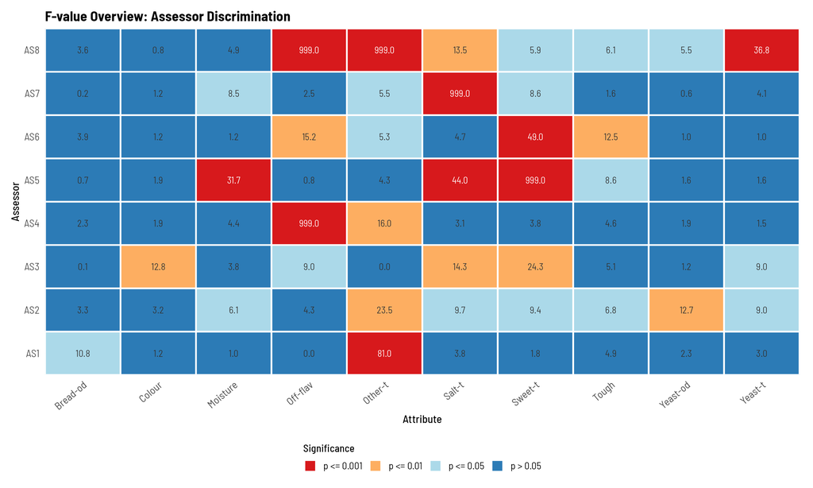

```r
knitr::include_graphics("figs/R/fvalue_heatmap.png")
```

## F-Value Dotplot

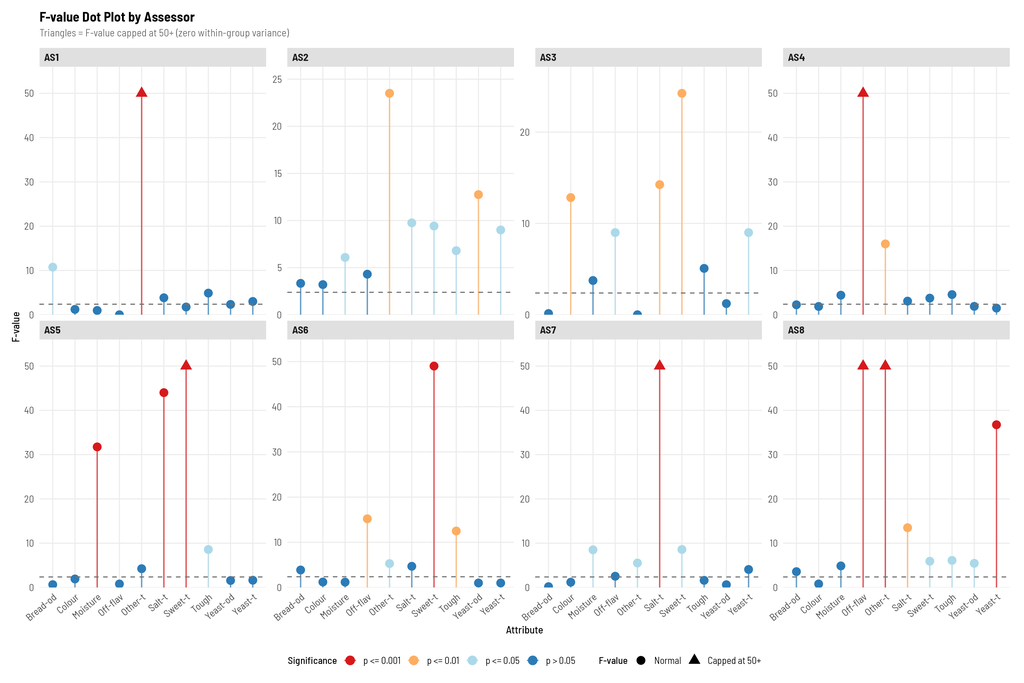

```r
knitr::include_graphics("figs/R/fvalue_dotplot.png")
```

## P-Value Heatmap

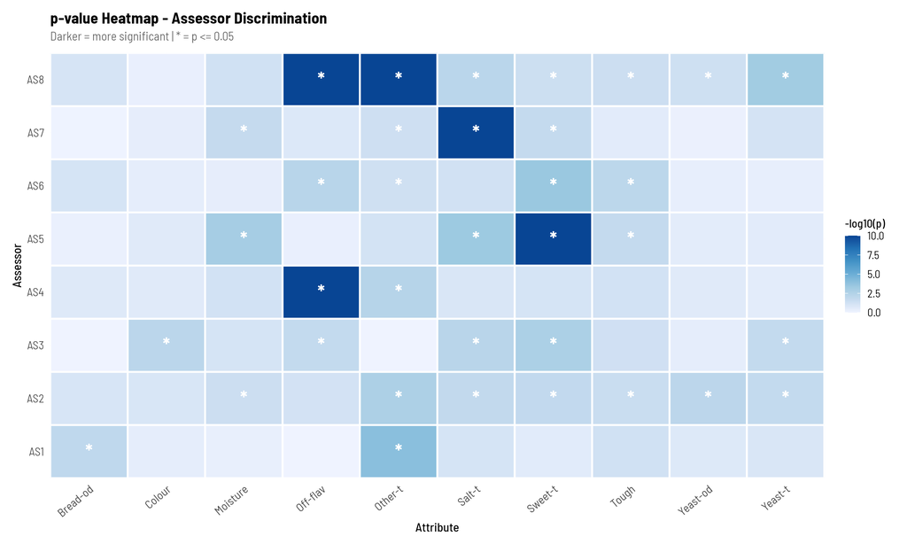

```r
knitr::include_graphics("figs/R/pvalue_heatmap.png")
```

## Panel ANOVA F-Values Plot

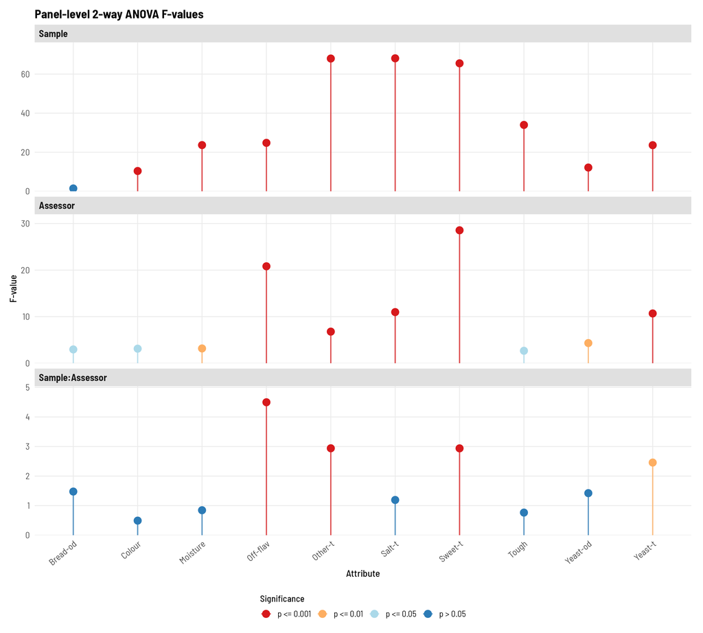

```r
knitr::include_graphics("figs/R/panel_anova_fvalues.png")
```

# Profile Plots

> **Note:** One representative assessor profile (AS1) is shown below. Profiles for all eight assessors are available in `figs/R/` and were generated using `02_profile_plots.R`.

## Assessor Profile (AS1)

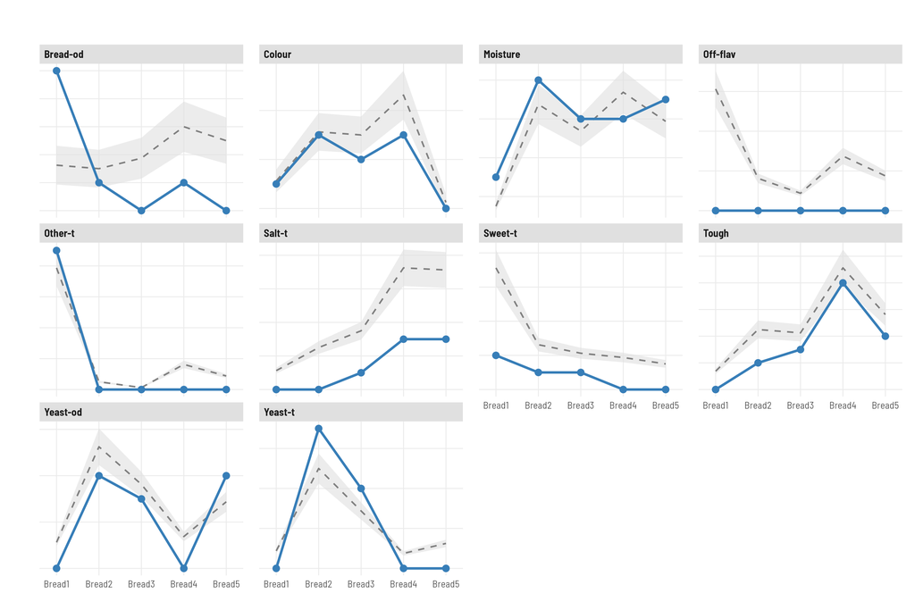

```r
knitr::include_graphics("figs/R/profile_AS1.png")
```

## All Assessors Overview

The combined overview plot displays all assessors on a single figure, facilitating rapid identification of outliers or systematic scale deviations.

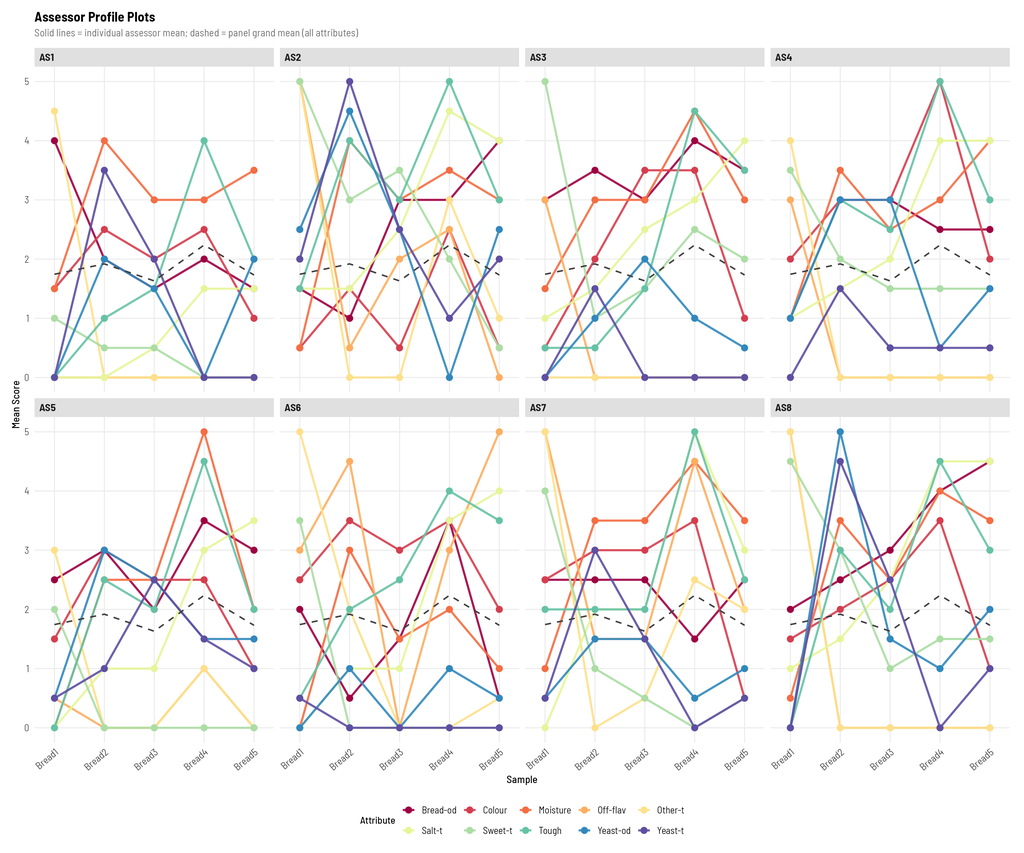

```r
knitr::include_graphics("figs/R/profile_all_assessors.png")
```

## Spider Plot

The spider (radar) chart displays panel mean scores for each sample across all attributes simultaneously, making it straightforward to compare overall sensory profiles between products.

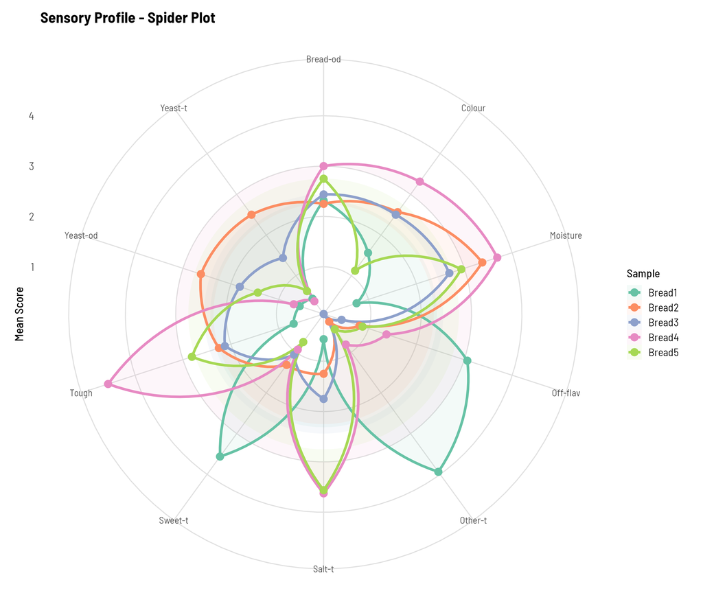

```r
knitr::include_graphics("figs/R/spider_plot.png")
```

# Mixed Model ANOVA

A linear mixed model is fitted per attribute using `lmerTest`, with **Sample** as a fixed effect and **Assessor**, **Assessor:Replicate**, and **Assessor:Sample** as random effects. This approach accounts for the hierarchical structure of panel data and provides more accurate inference than a standard ANOVA.

**Model formula:**

```
score ~ Sample + (1 | Assessor) + (1 | Assessor:Replicate) + (1 | Assessor:Sample)
```

## Fixed Effects

The fixed effects table reports the **F-statistic and p-value for the overall Sample effect** per attribute, derived from the mixed model using Satterthwaite denominator df approximation (lmerTest). This is an omnibus test of whether any sample differences exist — it does not identify which specific samples differ (see the Tukey HSD section for pairwise comparisons). A significant result confirms the panel reliably distinguishes between products on that attribute.

```r
tables[["mixed_model_fixed"]] |>
  gt() |>
  tab_header(
    title    = "Table 10. Mixed Model Fixed Effects",
    subtitle = "F-test statistics for the Sample effect per attribute (Satterthwaite df)"
  ) |>
  .gt_style()
```

Table 10. Mixed Model Fixed Effects

F-test statistics for the Sample effect per attribute (Satterthwaite df)

| Attribute | F_value | df_num | df_den | p_value | sig |
| --- | --- | --- | --- | --- | --- |
| Bread-od | 0.97 | 4.00 | 28.00 | 0.44 | ns |
| Yeast-od | 8.54 | 4.00 | 28.00 | 0.00 | *** |
| Off-flav | 5.51 | 4.00 | 28.00 | 0.00 | ** |
| Colour | 15.60 | 4.00 | 60.00 | 0.00 | *** |
| Moisture | 27.98 | 4.00 | 28.00 | 0.00 | *** |
| Tough | 44.40 | 4.00 | 28.00 | 0.00 | *** |
| Salt-t | 57.11 | 4.00 | 28.00 | 0.00 | *** |
| Sweet-t | 22.30 | 4.00 | 28.00 | 0.00 | *** |
| Yeast-t | 9.60 | 4.00 | 28.00 | 0.00 | *** |
| Other-t | 23.12 | 4.00 | 28.00 | 0.00 | *** |

*Significance key:* `***` p < 0.001 · `**` p < 0.01 · `*` p < 0.05 · `ns` p ≥ 0.05

## Random Effects

Variance components quantify each random term’s share of total variability. **% of total** shows each component’s proportional contribution. The **Assessor:Sample ratio** (Assessor:Sample ÷ Residual) is the primary diagnostic for panel consensus — values below 1.0 indicate residual noise exceeds the signal; values above 2.0 indicate high disagreement on sample ordering. Row colour reflects the QC flag for each component.

```r
if (!is.null(tables[["vc_flags"]])) {
  .dt_flag_rows(
    tables[["vc_flags"]],
    caption     = "Table 11. Mixed model random effects — variance components with QC flags per attribute.",
    page_length = 20
  )
} else {
  tables[["mixed_model_random"]] |>
    mutate(across(where(is.numeric), \(x) round(x, 2))) |>
    datatable(
      filter    = "top",
      rownames  = FALSE,
      extensions = "Buttons",
      options   = list(
        dom        = "Bfrtip",
        buttons    = c("csv", "excel"),
        pageLength = 15,
        scrollX    = TRUE
      ),
      caption = "Table 11. Mixed model random effects variance components per attribute."
    )
}
```

| Attribute | Component | Variance | Std_Dev | pct_total | as_ratio | flag | descriptor |
| --- | --- | --- | --- | --- | --- | --- | --- |
| Bread-od | Assessor:Sample | 0.27 | 0.52 | 17.82 | 0.25 | 🔴 | Residual exceeds disagreement — unreliable panel signal |
| Bread-od | Assessor:Replicate | 0 | 0 | 0 |  | 🟡 | Near-zero variance — check replicate blinding |
| Bread-od | Assessor | 0.17 | 0.41 | 10.81 |  | 🟢 | Low scale bias |
| Bread-od | Residual | 1.1 | 1.05 | 71.38 |  |  |  |
| Yeast-od | Assessor:Sample | 0.22 | 0.47 | 15.64 | 0.24 | 🔴 | Residual exceeds disagreement — unreliable panel signal |
| Yeast-od | Assessor:Replicate | 0.02 | 0.14 | 1.33 |  | 🟢 | Good session consistency |
| Yeast-od | Assessor | 0.27 | 0.52 | 18.87 |  | 🟢 | Low scale bias |
| Yeast-od | Residual | 0.91 | 0.95 | 64.16 |  |  |  |
| Off-flav | Assessor:Sample | 1.21 | 1.1 | 39.96 | 1.76 | 🟡 | Moderate disagreement on sample ordering |
| Off-flav | Assessor:Replicate | 0 | 0 | 0 |  | 🟡 | Near-zero variance — check replicate blinding |

[output cut: 30 more lines]

> ⚠️ **Note:** Performance flags are based on widely used guidelines in sensory science. Thresholds may be adjusted to reflect panel context, product category, and institutional SOPs.

## Variance Breakdown

The stacked bar chart partitions total variance per attribute into four sources: **Assessor** (individual scale use), **Assessor:Replicate** (session consistency), **Assessor:Sample** (disagreement on sample ordering), and **Residual** (unexplained error). A large Assessor:Sample proportion relative to Residual indicates the panel disagrees on how samples are ranked.

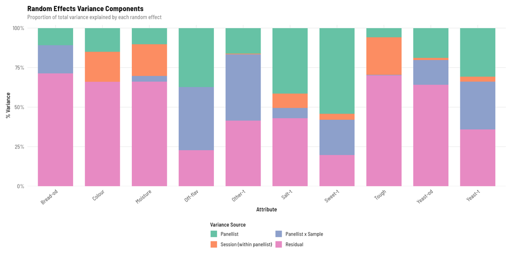

```r
knitr::include_graphics("figs/R/variance_components.png")
```

# Post-hoc Analysis — Tukey HSD

Where the mixed model identifies a significant Sample effect, a Tukey HSD post-hoc test is applied to determine which specific sample pairs differ. Compact letter display (CLD) groups are assigned such that samples sharing a letter do not differ significantly at α = 0.05.

## Estimated Marginal Means

Estimated marginal means (EMMs) are model-adjusted sample means that account for imbalance and random effects. They provide the best estimates of true sample differences per attribute.

```r
.dt_plain(tables[["tukey_emmeans"]],
          caption = "Table 12. Estimated marginal means (EMMs) per sample and attribute.")
```

| Attribute | Sample | emmean | SE | lower_CL | upper_CL |
| --- | --- | --- | --- | --- | --- |
| Bread-od | Bread1 | 2.31 | 0.35 | 1.6 | 3.03 |
| Bread-od | Bread2 | 2.25 | 0.35 | 1.53 | 2.97 |
| Bread-od | Bread3 | 2.44 | 0.35 | 1.72 | 3.15 |
| Bread-od | Bread4 | 3 | 0.35 | 2.28 | 3.72 |
| Bread-od | Bread5 | 2.75 | 0.35 | 2.03 | 3.47 |
| Yeast-od | Bread1 | 0.56 | 0.34 | -0.15 | 1.27 |
| Yeast-od | Bread2 | 2.62 | 0.34 | 1.92 | 3.33 |
| Yeast-od | Bread3 | 1.81 | 0.34 | 1.1 | 2.52 |
| Yeast-od | Bread4 | 0.69 | 0.34 | -0.02 | 1.4 |
| Yeast-od | Bread5 | 1.44 | 0.34 | 0.73 | 2.15 |

[output cut: 40 more lines]

## Compact Letter Display

CLD group letter per sample–attribute combination. Samples sharing a letter do not differ significantly at α = 0.05.

```r
.dt_plain(tables[["tukey_cld"]],
          caption = "Table 13. Compact letter display (CLD) groups from Tukey HSD.")
```

| Attribute | Sample | emmean | SE | letter |
| --- | --- | --- | --- | --- |
| Bread-od | Bread2 | 2.25 | 0.35 | a |
| Bread-od | Bread1 | 2.31 | 0.35 | a |
| Bread-od | Bread3 | 2.44 | 0.35 | a |
| Bread-od | Bread5 | 2.75 | 0.35 | a |
| Bread-od | Bread4 | 3 | 0.35 | a |
| Yeast-od | Bread1 | 0.56 | 0.34 | a |
| Yeast-od | Bread4 | 0.69 | 0.34 | ab |
| Yeast-od | Bread5 | 1.44 | 0.34 | abc |
| Yeast-od | Bread3 | 1.81 | 0.34 | bc |
| Yeast-od | Bread2 | 2.62 | 0.34 | c |

[output cut: 40 more lines]

## Pairwise Contrasts

Full pairwise contrast table showing estimated differences, standard errors, t-ratios, and adjusted p-values for every sample pair per attribute.

```r
.dt_plain(tables[["tukey_contrasts"]],
          caption = "Table 14. Tukey HSD pairwise contrasts per attribute.")
```

| Attribute | contrast | estimate | SE | df | t_ratio | p_adj | sig |
| --- | --- | --- | --- | --- | --- | --- | --- |
| Bread-od | Bread1 - Bread2 | 0.06 | 0.45 | 28 | 0.14 | 1 | ns |
| Bread-od | Bread1 - Bread3 | -0.13 | 0.45 | 28 | -0.28 | 1 | ns |
| Bread-od | Bread1 - Bread4 | -0.69 | 0.45 | 28 | -1.51 | 0.56 | ns |
| Bread-od | Bread1 - Bread5 | -0.44 | 0.45 | 28 | -0.96 | 0.87 | ns |
| Bread-od | Bread2 - Bread3 | -0.19 | 0.45 | 28 | -0.41 | 0.99 | ns |
| Bread-od | Bread2 - Bread4 | -0.75 | 0.45 | 28 | -1.65 | 0.48 | ns |
| Bread-od | Bread2 - Bread5 | -0.5 | 0.45 | 28 | -1.1 | 0.8 | ns |
| Bread-od | Bread3 - Bread4 | -0.56 | 0.45 | 28 | -1.24 | 0.73 | ns |
| Bread-od | Bread3 - Bread5 | -0.31 | 0.45 | 28 | -0.69 | 0.96 | ns |
| Bread-od | Bread4 - Bread5 | 0.25 | 0.45 | 28 | 0.55 | 0.98 | ns |

[output cut: 90 more lines]

*Significance key:* `***` p < 0.001 · `**` p < 0.01 · `*` p < 0.05 · `ns` p ≥ 0.05

## Means & CLD Plot

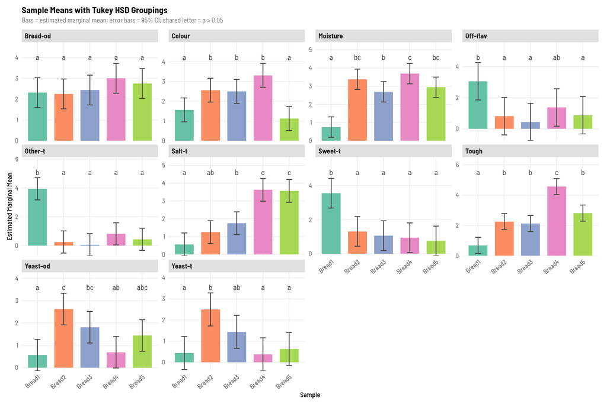

```r
knitr::include_graphics("figs/R/tukey_means_cld.png")
```

## Pairwise P-value Heatmap

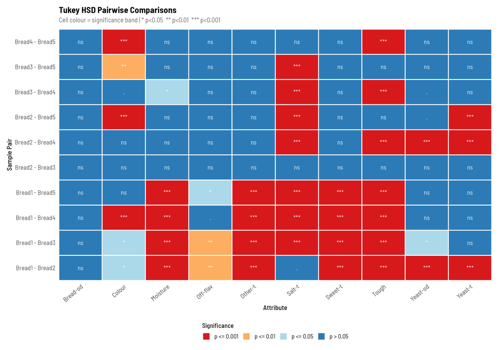

```r
knitr::include_graphics("figs/R/tukey_heatmap.png")
```

# Consensus PCA

Principal Component Analysis (PCA) is performed on the **consensus matrix** — the grand mean of all assessor scores per sample and attribute, averaged across replicates. This provides a low-dimensional representation of sample and attribute relationships as perceived by the panel as a whole.

## Biplot

The biplot overlays sample scores (points) and attribute loadings (arrows) in the space defined by the first two principal components. Samples close together are perceived as similar; attributes pointing in the same direction are positively correlated.

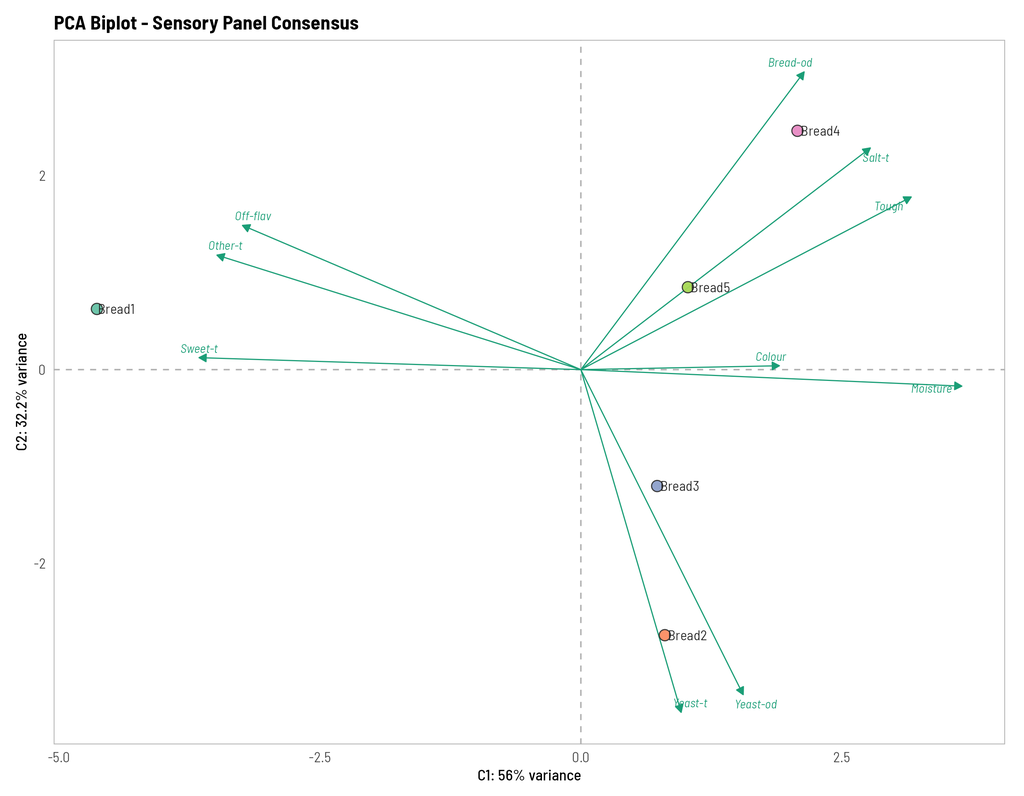

```r
knitr::include_graphics("figs/R/pca_biplot.png")
```

## Scree Plot

The scree plot shows the percentage of variance explained by each principal component, along with a cumulative variance line. Components to the left of the elbow are typically retained for interpretation.

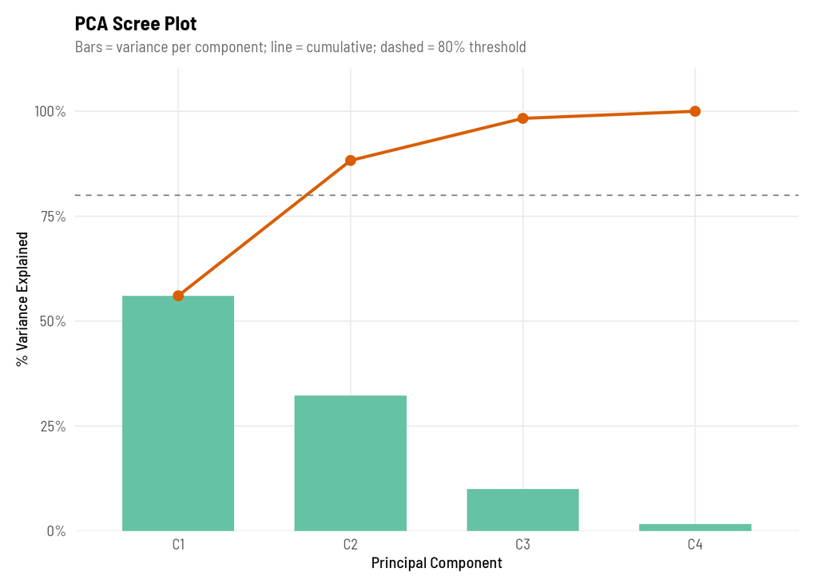

```r
knitr::include_graphics("figs/R/pca_scree.png")
```

## Variable Loadings

Loading bars show the contribution of each sensory attribute to the first two principal components. Longer bars indicate attributes that drive the most variation in the consensus space.

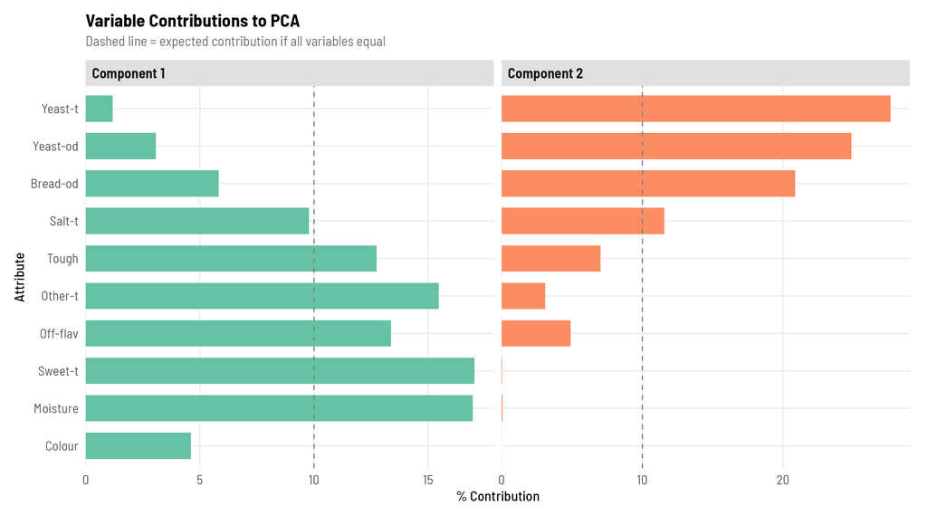

```r
knitr::include_graphics("figs/R/pca_loadings.png")
```

## Sample Coordinates

The sample coordinate table reports the PCA scores (position on each component) for every sample. These values correspond to the point positions in the biplot.

```r
tables[["pca_sample_coords"]] |>
  gt() |>
  tab_header(
    title    = "Table 15. PCA Sample Coordinates",
    subtitle = "Consensus matrix scores projected onto principal components"
  ) |>
  .gt_style()
```

Table 15. PCA Sample Coordinates

Consensus matrix scores projected onto principal components

| Sample | x | y | Dim.3 | Dim.4 |
| --- | --- | --- | --- | --- |
| Bread1 | −4.64 | 0.63 | 0.19 | 0.03 |
| Bread2 | 0.80 | −2.74 | 0.52 | 0.47 |
| Bread3 | 0.73 | −1.20 | −0.03 | −0.76 |
| Bread4 | 2.07 | 2.46 | 1.15 | 0.07 |
| Bread5 | 1.03 | 0.85 | −1.84 | 0.19 |

## Variable Coordinates

The variable coordinate table reports the PCA loadings (contribution of each attribute to each component), corresponding to the arrow endpoints in the biplot.

```r
tables[["pca_variable_coords"]] |>
  gt() |>
  tab_header(
    title    = "Table 16. PCA Variable Coordinates (Loadings)",
    subtitle = "Sensory attribute contributions to each principal component"
  ) |>
  .gt_style()
```

Table 16. PCA Variable Coordinates (Loadings)

Sensory attribute contributions to each principal component

| variable | Dim.1 | Dim.2 | x | y |
| --- | --- | --- | --- | --- |
| Yeast-t | 0.26 | −0.94 | 0.96 | −3.53 |
| Yeast-od | 0.42 | −0.90 | 1.55 | −3.35 |
| Bread-od | 0.57 | 0.82 | 2.14 | 3.07 |
| Salt-t | 0.74 | 0.61 | 2.77 | 2.29 |
| Tough | 0.85 | 0.48 | 3.16 | 1.78 |
| Other-t | −0.93 | 0.32 | −3.49 | 1.18 |
| Off-flav | −0.87 | 0.40 | −3.24 | 1.49 |
| Sweet-t | −0.98 | 0.03 | −3.66 | 0.12 |
| Moisture | 0.97 | −0.05 | 3.65 | −0.17 |
| Colour | 0.51 | 0.01 | 1.90 | 0.04 |

Analysis pipeline: `R/run_all.R` · Original PanelCheck application by [CPHFOOD](https://github.com/CPHFOOD/PanelCheck) · R translation developed with assistance from **Claude Code** (Anthropic) · [Get the R script](https://github.com/JoshLomax/PanelCheck/tree/feature/r-translation)